# P-Value 2 Linear

Nate Breznau

9/24/2021

### P-Value 2. Linear Associations

Instead of comparing discrete groups (like high and low income in the previous example 01_pvalue_means.Rmd), social scientists often want to investigate a linear association. Thinking carefully about income and happiness, these are variables that are most likely continuous. People have scales of income and happiness, at least in theory.

```r
# load data
wvs_pvalue <- read_rds(here::here("data","wvs_pvalue.rds"))

wvs_pvalue <- wvs_pvalue %>%
  subset(!is.na(income8) & !is.na(happiness) & !is.na(life_sat)) %>%
  mutate(happy = ifelse(happiness > 0, happiness, NA), # remove missing
         happy = car::recode(happy, "1=4;2=3;3=2;4=1"),
         life_sati = ifelse(life_sat > 0, life_sat, NA),
         happyZ = scale(happy),
         life_satiZ = scale(life_sati),
         income8f = ifelse(income8 > 0, income8, NA)) %>%
  rowwise() %>%
  mutate(subj_well_being = mean(c(happyZ,life_satiZ), na.rm = T))
```

Plot Linear Association

Let us again take the example of Germany so that we do not have too many cases in the visualization.

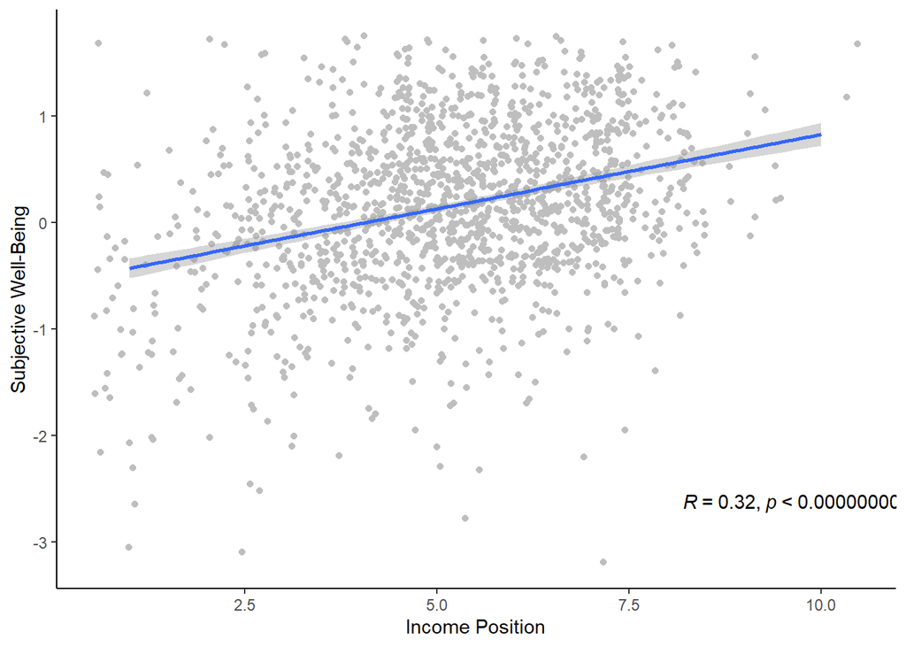

```r
set.seed(90210)
jitter <- position_jitter(width = 0.5, height = 0.5)

wvs_pvalue %>%
  subset(iso3c == "DEU") %>%
  ggplot(aes(x = income8f, y = subj_well_being)) +
  geom_point(color = "grey", position = jitter) +
  geom_smooth(method = "lm") +
  stat_cor(p.digits = 3, label.y.npc = 0.1, label.x.npc = 0.8) +
  labs(x = "Income Position", y = "Subjective Well-Being") +
  theme_classic()
```

We know that Ethiopia did not have an association between income and happiness, let’s test that here with continuous variables. We can plot all results, for each country while we are at it.

```r
set.seed(90210)
jitter <- position_jitter(width = 0.5, height = 0.5)


for (c in unique(wvs_pvalue$iso3c)) {
  wvs_pvalue_temp <- wvs_pvalue %>%
    subset(iso3c == c)

  # custom titles for each plot
  gtitle <- countrycode(c, "iso3c", "country.name", custom_match = c("AND" = "Andorra"))

  plot_temp <-   ggplot(wvs_pvalue_temp, aes(x = income8f, y = subj_well_being)) +
    geom_point(color = "grey", position = jitter) +
    geom_smooth(method = "lm") +
    stat_cor(p.accuracy = 0.001,
             label.y = -2.5, label.x = 5) +
    labs(x = "Income Position", y = "Subjective Well-Being",
         title = paste0(gtitle, " (", c, ")")) +
    ylim(c(-3,2)) +
    xlim(c(1,10)) +
  theme_classic()


agg_png(here::here("results", "linear_p", paste0(c,"_linear.png")), height = 700, width = 500, res = 144)
print(plot_temp)
dev.off()
}
```

We observe that in Ethiopia that the fitted line between subjective well-being and income position is different from zero.

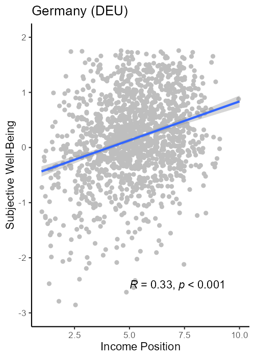

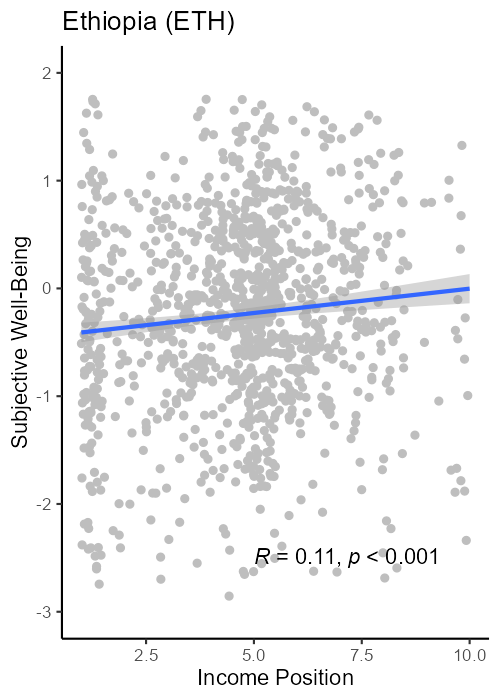

```r
knitr::include_graphics(c(here::here("results", "linear_p", "DEU_linear.png"), here::here("results", "linear_p", "ETH_linear.png")))
```